# Biostat M280 Homework 3 by Huijun An

Due Mar 1 @ 11:59PM

Use tidyverse and bash to explore following two data sets.

## Q1 LA City Employee Payroll

The `/home/m280data/la_payroll/City_Employee_Payroll.csv` file on teaching server contains payroll information of LA City employees in years 2013-2018. It was downloaded from [LA City Controller’s Office](https://controllerdata.lacity.org/Payroll/City-Employee-Payroll/pazn-qyym). Make a Shiny app to facilitate visualization of this data.

1. For efficiency of the Shiny app, you should first pre-process, pare down, tidy, and save the data, e.g., as a compressed RDS file, to be used in the app.
2. **Total payroll by LA City**. Visualize the total LA City payroll of each year, with breakdown into base pay, overtime pay, and other pay.
3. **Who earned most?** Visualize the payroll information (total payment with breakdown into base pay, overtime pay, and other pay, Department, Job Title) of the top $n$ highest paid LA City employees in a specific year. User specifies $n$ (default 10) and year (default 2017).
4. **Which departments earn most?** Visualize the mean or median payroll, with breakdown into base pay, overtime pay, and other pay, of top $n$ earning departments. User specifies $n$ (default 5), year (default 2017), and method (mean or median, default median).
5. **Which departments cost most?** Visualize the total payroll, with breakdown into base pay, overtime pay, and other pay, of top $n$ expensive departments. User specifies $n$ (default 5) and year (default 2017).
6. Visualize any other information you are interested in.
7. Publish your Shiny app to https://www.shinyapps.io and share the link.

**Solution** link: https://huijunan.shinyapps.io/M280HW3Q1_LA_Payroll/

## Q2 LA City Parking War

The SQLite database `/home/m280data/la_parking/LA_Parking_Citations.sqlite` on teaching server contains information about parking tickets in LA City. It was downloaded from [LA Open Data Portal](https://data.lacity.org/A-Well-Run-City/Parking-Citations/wjz9-h9np). Connect to the database and answer following questions using plots and summary statistics. In this exercise, you are **not** allowed to load whole data into memory. Use the *transform in database, plot in R* strategy.

```r
library("DBI")
library("RSQLite")

library("dplyr")
library("dbplyr")
citation <- dbConnect(RSQLite::SQLite(), dbname = "/home/m280data/la_parking/LA_Parking_Citations.sqlite")
dbListTables(citation)
```

```
## [1] "latix"
```

```r
PC_sql <- dplyr::tbl(citation, "latix")
```

1. How many tickets are in this data set? Which time period do these tickets span? Which years have most data?

```r
PC_sql %>% summarize(n())
```

```
## # Source:   lazy query [?? x 1]
## # Database: sqlite 3.22.0
## #   [/home/m280data/la_parking/LA_Parking_Citations.sqlite]
##     `n()`
##     <int>
## 1 7656418
```

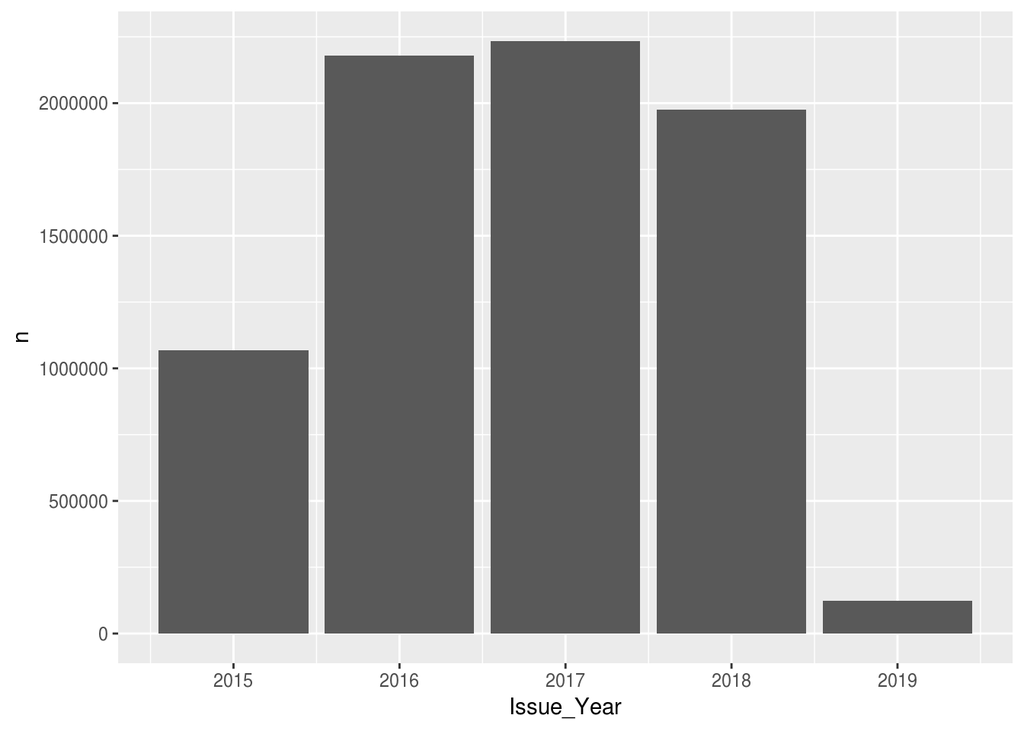

```r
library(ggplot2)
PC_sql %>%
  group_by (Issue_Year) %>%
  filter(is.na(Issue_Year)==F) %>%
  summarize(n = n()) %>%
  ggplot() +
    geom_col(aes(x = Issue_Year, y = n))
```

```r
PC_sql %>%
  filter(is.na(Issue_DateTime)==F) %>%
  arrange(desc(Issue_DateTime)) %>%
  collect() %>%
  slice(c(1,n())) %>%
  select(Issue_Year, Issue_Month, Issue_Day, Issue_Hour, Issue_Minute)
```

```
## # A tibble: 2 x 5
##   Issue_Year Issue_Month Issue_Day Issue_Hour Issue_Minute
##        <int>       <int>     <int>      <int>        <int>
## 1       2019           1        25         23           58
## 2       2015           7         2          1            0
```

```r
PC_sql %>%
  group_by (Make) %>%
  filter(is.na(Make)==F) %>%
  summarize(n = n()) %>%
  arrange(desc(n)) %>%
  collect() %>%
  slice(1)
```

```
## # A tibble: 1 x 2
##   Make        n
##   <chr>   <int>
## 1 TOYT  1270804
```

**Solution** There are 7656418 in this data set. The time span is 07/02/2015 1:00 am to 01/25/2019 23:58 pm. And based on the histogram we can tell that Year 2017 has the most data.

0. When (which hour, weekday, month day, and month) are you most likely to get a ticket and when are you least likely to get a ticket?

**Solution**

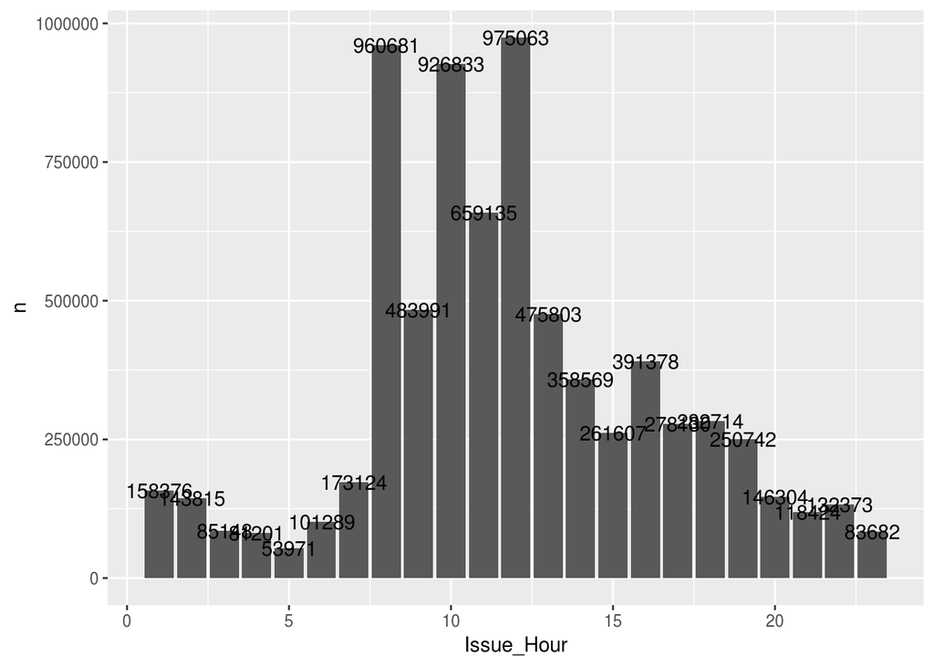

```r
library(ggplot2)
PC_sql %>%
  group_by (Issue_Hour) %>%
  filter(is.na(Issue_Hour)==F) %>%
  summarize(n = n()) %>%
  ggplot() +
    geom_col(aes(x = Issue_Hour, y = n)) +
    geom_text(aes(x = Issue_Hour, y = n, label = n))
```

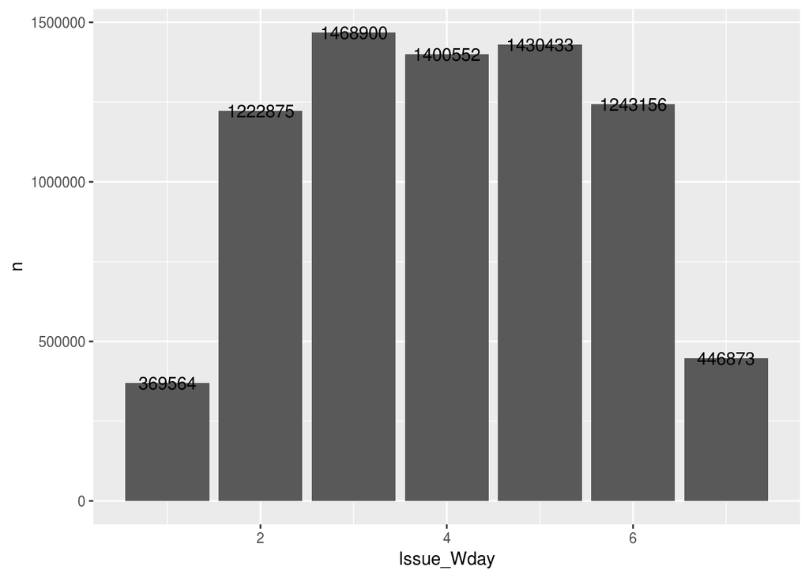

```r
PC_sql %>%
  group_by (Issue_Wday) %>%
  filter(is.na(Issue_Wday)==F) %>%
  summarize(n = n()) %>%
  ggplot() +
    geom_col(aes(x = Issue_Wday, y = n)) +
    geom_text(aes(x = Issue_Wday, y = n, label = n))
```

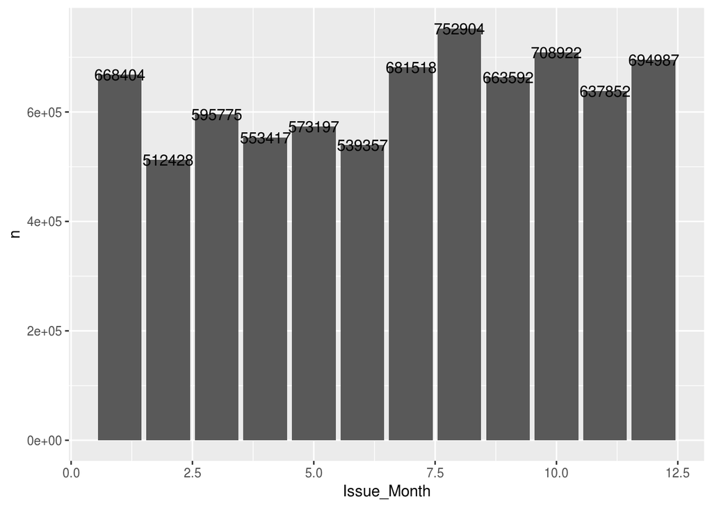

```r
PC_sql %>%
  group_by (Issue_Month) %>%
  filter(is.na(Issue_Month)==F) %>%
  summarize(n = n()) %>%
  ggplot() +
    geom_col(aes(x = Issue_Month, y = n)) +
    geom_text(aes(x = Issue_Month, y = n, label = n))
```

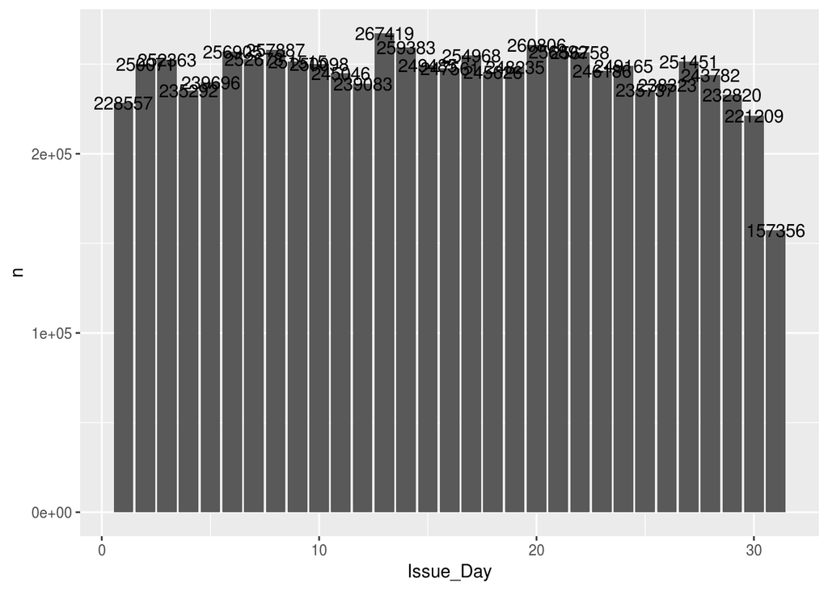

```r
PC_sql %>%
  group_by (Issue_Day) %>%
  filter(is.na(Issue_Day)==F) %>%
  summarize(n = n()) %>%
  ggplot() +
    geom_col(aes(x = Issue_Day, y = n)) +
    geom_text(aes(x = Issue_Day, y = n, label = n))
```

```r
PC_sql %>%
  group_by (Issue_Day) %>%
  filter(is.na(Issue_Day)==F) %>%
  summarize(n = n()) %>%
  arrange(desc(n)) %>%
  collect() %>%
  slice(c(1,n()))
```

```
## # A tibble: 2 x 2
##   Issue_Day      n
##       <int>  <int>
## 1        13 267419
## 2        31 157356
```

0. Which car makes received most citations?

```r
PC_sql %>%
  group_by (Make) %>%
  filter(is.na(Make)==F) %>%
  summarize(n = n()) %>%
  arrange(desc(n)) %>%
  collect() %>%
  slice(1)
```

```
## # A tibble: 1 x 2
##   Make        n
##   <chr>   <int>
## 1 TOYT  1270804
```

**Solution** Toyota is the car make that gets the most citations.

0. How many different colors of cars were ticketed? Which color attracted most tickets?

```r
PC_sql %>%
  group_by (Color) %>%
  filter(is.na(Color)==F) %>%
  summarize(n = n()) %>%
  arrange(desc(n)) %>%
  collect()
```

```
## # A tibble: 103 x 2
##    Color       n
##    <chr>   <int>
##  1 BK    1652621
##  2 WT    1603566
##  3 GY    1497021
##  4 SL     953903
##  5 BL     591858
##  6 RD     378515
##  7 GN     213197
##  8 BN     148980
##  9 GO      97961
## 10 MR      91279
## # ... with 93 more rows
```

**Solution** Total of 103 colors of cars were tickted and among them the color Black attracted most tickets.

0. What are the most common ticket types?

```r
PC_sql %>%
  group_by (Violation_code) %>%
  filter(is.na(Violation_code)==F) %>%
  summarize(n = n()) %>%
  arrange(desc(n)) %>%
  collect() %>%
  slice(1)
```

```
## # A tibble: 1 x 2
##   Violation_code       n
##   <chr>            <int>
## 1 80.69BS        2166602
```

**Solution** The most common ticket type has the violation code 80.69BS which stands for NO PARK/STREET CLEAN.

0. How much money was collected on parking tickets in 2016, 2017 and 2018?

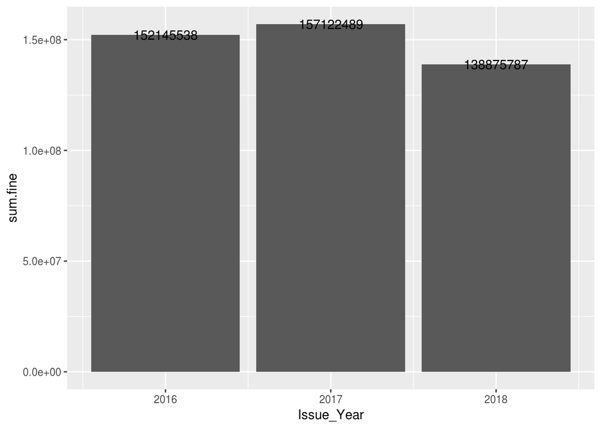

```r
PC_sql %>%
  group_by (Issue_Year) %>%
  filter(Issue_Year == 2016  | Issue_Year == 2017 | Issue_Year == 2018) %>%
  summarize(sum.fine=sum(Fine_amount,na.rm=T)) %>%
  collect() %>%
  ggplot() +
    geom_col(aes(x = Issue_Year, y = sum.fine)) +
    geom_text(aes(x = Issue_Year, y = sum.fine, label = sum.fine))
```

**Solution** Total of $152145538 were collected in Year 2016, $157122489 were collected in Year 2017 and $138875787 were collected in Year 2018.

0. If you’ve been ticketed in LA County, did you find your ticket in this data set?

**Solution** Never been ticketed in LA County, Proud of myself!

```r
dbDisconnect(citation)
```

0. Read the blog http://www.brettrics.com/9-million-parking-tickets-la/ and try to reproduce plots using your data.